# 2.viewing

# Viewing and understanding the training data

## Loading the data

We load from the compiled, preformatted data saved earlier :

```r
load("d.train.RData")
load("im.train.RData")
load("im.test.RData")
ls()
```

```
## [1] "d.key.mean"       "d.key.mean.all"   "d.train"
## [4] "d.train.complete" "im.test"          "im.train"
## [7] "m.key.mean"       "m.key.mean.all"
```

## Basic quantitative summaries

```r
dim(d.train)
```

```
## [1] 7049   30
```

```r
dim(im.train)
```

```
## [1] 7049 9216
```

```r
dim(im.test)
```

```
## [1] 1783 9216
```

```r
summary(d.train, digits = 1)[c(1,3,4,6),]
```

```
##  left_eye_center_x left_eye_center_y right_eye_center_x right_eye_center_y
##  Min.   :23        Min.   : 2        Min.   : 0.7       Min.   : 4
##  Median :66        Median :38        Median :30.3       Median :38
##  Mean   :66        Mean   :38        Mean   :30.3       Mean   :38
##  Max.   :95        Max.   :81        Max.   :85.0       Max.   :81
##  left_eye_inner_corner_x left_eye_inner_corner_y left_eye_outer_corner_x
##  Min.   :19              Min.   :27              Min.   :28
##  Median :59              Median :38              Median :73
##  Mean   :59              Mean   :38              Mean   :73
##  Max.   :84              Max.   :67              Max.   :95
##  left_eye_outer_corner_y right_eye_inner_corner_x right_eye_inner_corner_y
##  Min.   :26              Min.   : 6               Min.   :26
##  Median :38              Median :37               Median :38
##  Mean   :38              Mean   :37               Mean   :38
##  Max.   :65              Max.   :71               Max.   :70
##  right_eye_outer_corner_x right_eye_outer_corner_y
##  Min.   : 4               Min.   :25
##  Median :23               Median :38
##  Mean   :22               Mean   :38
##  Max.   :61               Max.   :71
##  left_eyebrow_inner_end_x left_eyebrow_inner_end_y
##  Min.   :18               Min.   :16
##  Median :56               Median :30
##  Mean   :56               Mean   :29
##  Max.   :80               Max.   :61
##  left_eyebrow_outer_end_x left_eyebrow_outer_end_y
##  Min.   :32               Min.   :11
##  Median :80               Median :30
##  Mean   :79               Mean   :30
##  Max.   :94               Max.   :60
##  right_eyebrow_inner_end_x right_eyebrow_inner_end_y
##  Min.   : 7                Min.   :16
##  Median :39                Median :30
##  Mean   :39                Mean   :30
##  Max.   :77                Max.   :62
##  right_eyebrow_outer_end_x right_eyebrow_outer_end_y   nose_tip_x
##  Min.   : 4                Min.   :13                Min.   :13
##  Median :16                Median :30                Median :48
##  Mean   :16                Mean   :30                Mean   :48
##  Max.   :58                Max.   :67                Max.   :89
##    nose_tip_y mouth_left_corner_x mouth_left_corner_y mouth_right_corner_x
##  Min.   :18   Min.   :23          Min.   :57          Min.   : 2
##  Median :63   Median :63          Median :76          Median :33
##  Mean   :63   Mean   :63          Mean   :76          Mean   :33
##  Max.   :96   Max.   :85          Max.   :95          Max.   :74
##  mouth_right_corner_y mouth_center_top_lip_x mouth_center_top_lip_y
##  Min.   :57           Min.   :13             Min.   :57
##  Median :76           Median :48             Median :73
##  Mean   :76           Mean   :48             Mean   :73
##  Max.   :96           Max.   :84             Max.   :95
##  mouth_center_bottom_lip_x mouth_center_bottom_lip_y
##  Min.   :13                Min.   :26
##  Median :49                Median :79
##  Mean   :49                Mean   :79
##  Max.   :89                Max.   :96
```

## Missing analysis

As we can see below, **only the nose_tip** is garanteed to be present all the time. A few eye centers (13) and mouth centers (33) are missing, but most are present. A lot of the rest (~ 4800, i.e. ~ 70% ) are missing !

```r
as.matrix(summary(d.train, digits = 1)[7,])
```

```
##                           [,1]
## left_eye_center_x         "NA's   :10  "
## left_eye_center_y         "NA's   :10  "
## right_eye_center_x        "NA's   :13  "
## right_eye_center_y        "NA's   :13  "
## left_eye_inner_corner_x   "NA's   :4778  "
## left_eye_inner_corner_y   "NA's   :4778  "
## left_eye_outer_corner_x   "NA's   :4782  "
## left_eye_outer_corner_y   "NA's   :4782  "
## right_eye_inner_corner_x  "NA's   :4781  "
## right_eye_inner_corner_y  "NA's   :4781  "
## right_eye_outer_corner_x  "NA's   :4781  "
## right_eye_outer_corner_y  "NA's   :4781  "
## left_eyebrow_inner_end_x  "NA's   :4779  "
## left_eyebrow_inner_end_y  "NA's   :4779  "
## left_eyebrow_outer_end_x  "NA's   :4824  "
## left_eyebrow_outer_end_y  "NA's   :4824  "
## right_eyebrow_inner_end_x "NA's   :4779  "
## right_eyebrow_inner_end_y "NA's   :4779  "
## right_eyebrow_outer_end_x "NA's   :4813  "
## right_eyebrow_outer_end_y "NA's   :4813  "
##   nose_tip_x              NA
##   nose_tip_y              NA
## mouth_left_corner_x       "NA's   :4780  "
## mouth_left_corner_y       "NA's   :4780  "
## mouth_right_corner_x      "NA's   :4779  "
## mouth_right_corner_y      "NA's   :4779  "
## mouth_center_top_lip_x    "NA's   :4774  "
## mouth_center_top_lip_y    "NA's   :4774  "
## mouth_center_bottom_lip_x "NA's   :33  "
## mouth_center_bottom_lip_y "NA's   :33  "
```

Let’s check if x and y missing always match, as one would expect. More specifically, we are looking for a situation where either the x or the y value is NA, but not both, for the same keypoint.

```r
any(xor(is.na(d.train[, seq(1,30,2)]),is.na(d.train[, seq(2,30,2)])))
```

```
## [1] FALSE
```

Good. There is none.

## Plotting utility functions

Plotting the keypoints, as an overlay to an existing earlier image.

**Keys represent a dataframe where keys are the rows. Coordinates need to be adjusted, because matrix origin is top left, while display origin is bottom left.**

```r
m.plotKeypoints <- function(keys, col="red") {
  x <- 96 - as.numeric(keys[seq(1,30,2)])
  y <- 96 - as.numeric(keys[seq(2,30,2)])
  points(x,y,col=col)
  lines(mean(x),mean(y),col="yellow",pch=3)
  # x value for various parts
  le <- c(5,1,7) # left eye
  re <- c(11,3,9) #  right eye
  lb <- c(13,15) # left eyBrow
  rb <- c(17,19) # right eyeBrow
  mm <- c(23,27,25,29,23) # mouth

  lines(x = 96-keys[le],y=96-keys[le+1],col=col)
  lines(x = 96-keys[re],y=96-keys[re+1],col=col)
  lines(x = 96-keys[lb],y=96-keys[lb+1],col=col)
  lines(x = 96-keys[rb],y=96-keys[rb+1],col=col)
  lines(x = 96-keys[mm],y=96-keys[mm+1],col=col)

}
```

Plotting an image, optionnally with a title and keypoints.

**The image is a row 1 x 9296.**

```r
m.plotImage <- function(image=rep.int(128,9216), kp=NA , title=NA, col="red") {
  n <- sqrt(length(image))
  image(
    1:n,
    1:n,
    matrix(rev(image), nrow=n, ncol=n),
    col=gray((0:255)/255),asp=1.)
  if(!any(is.na(kp))) {
    m.plotKeypoints(kp,col)
  }
  if(!is.na(title)) {
    title(main=title)
  }
}
```

This is how it works :

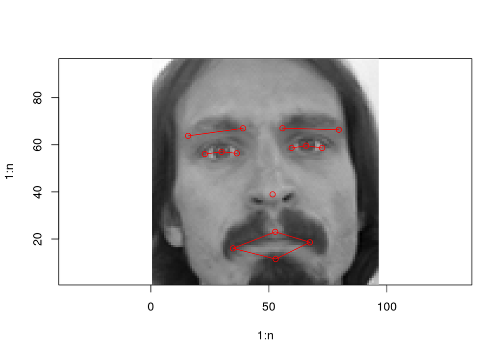

```r
m.plotImage(im.train[1,],kp = d.train[1,])
```

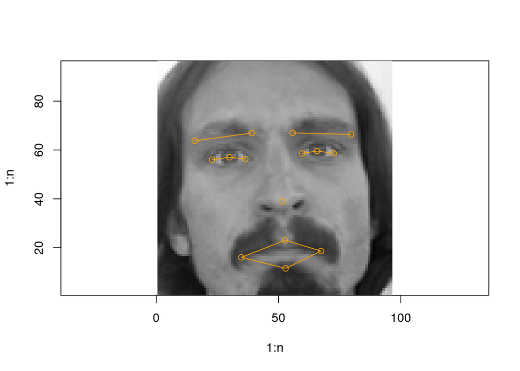

```r
m.plotImage(im.train[1,],kp = d.train[1,],col="orange")
```

## Symetries

The function m.mirror will produce a symetrical key w.r.t. the middle vertical axis, by replacing all left element with their right element, while mirorring all coordinates.

```r
m.mirrorKey <- function(key) {
  r <- key
  r[seq(1,30,2)] <- 96-key[seq(1,30,2)]
  left <-  c(1,5,7,13,15,23 ,    2,6,8,14,16,24)
  right <- c(3,9,11,17,19,25,    4,10,12,18,20,26 )
  a <- r[right]
  r[right] <- r[left]
  r[left] <- a
  return (r)
}
```

Let’s see on an example

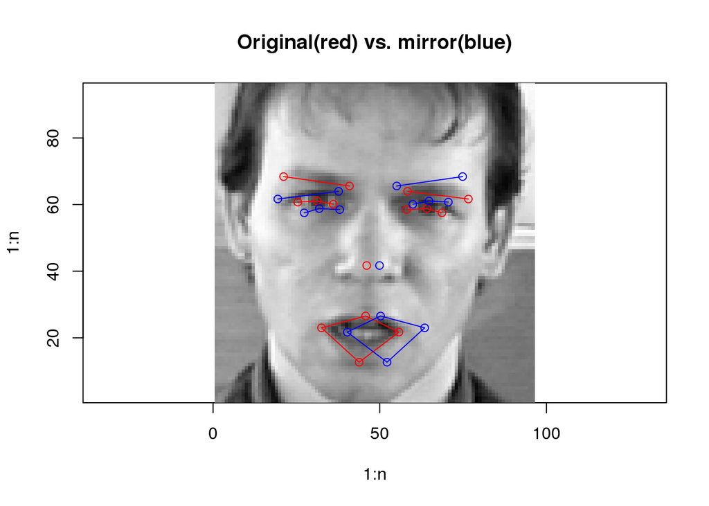

```r
m.plotImage(im.train[22,], kp=d.train[22,], col="red")
m.plotKeypoints(m.mirrorKey(d.train[22,]),col="blue")
title(main="Original(red) vs. mirror(blue)")
```

## Compute average figure

Let’s create the “average” figure from the complete training dataset.

```r
d.key.mean <-
  colMeans(na.omit(d.train))
  length(d.key.mean)
```

```
## [1] 30
```

Let’s compare this with the means we get using all non NA cell, even on incomplete lines.

```r
d.key.mean.all <- colMeans(d.train, na.rm = TRUE)
length(d.key.mean.all)
```

```
## [1] 30
```

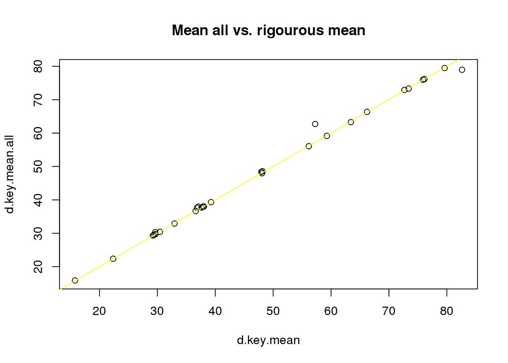

```r
plot(x=d.key.mean, y=d.key.mean.all )
title(main="Mean all vs. rigourous mean")
lines(x=c(0,95),y=c(0,95),col="yellow")
```

```r
sort(d.key.mean - d.key.mean.all)[-5:-26]
```

```
##                nose_tip_y        right_eye_center_y
##                -5.4619579                -0.9131277
##         left_eye_center_y        right_eye_center_x
##                -0.8089600                -0.6658329
##   left_eye_inner_corner_x       mouth_left_corner_x
##                 0.1127887                 0.1333410
##  left_eyebrow_outer_end_x mouth_center_bottom_lip_y
##                 0.1346973                 3.6602662
```

We see that there are only significant differences, when computing the means in both ways, for **“nose_tip_y”** and for **“mouth_center_bottom_lip_y”**

Graphically :

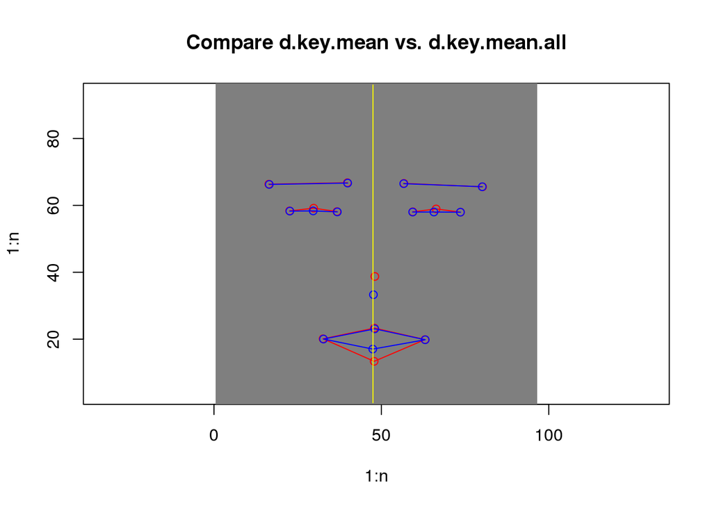

```r
m.plotImage()
m.plotKeypoints(d.key.mean,col="red")         # Moyenne sur elements strictement complets
m.plotKeypoints(d.key.mean.all,col="blue")    # Moyenne extensive
lines(x=c(95/2,95/2),y=c(1,96),col="yellow")  # Axe de symetrie latérale
title(main="Compare d.key.mean vs. d.key.mean.all")
```

Let’s check if we have symetry issues here ?

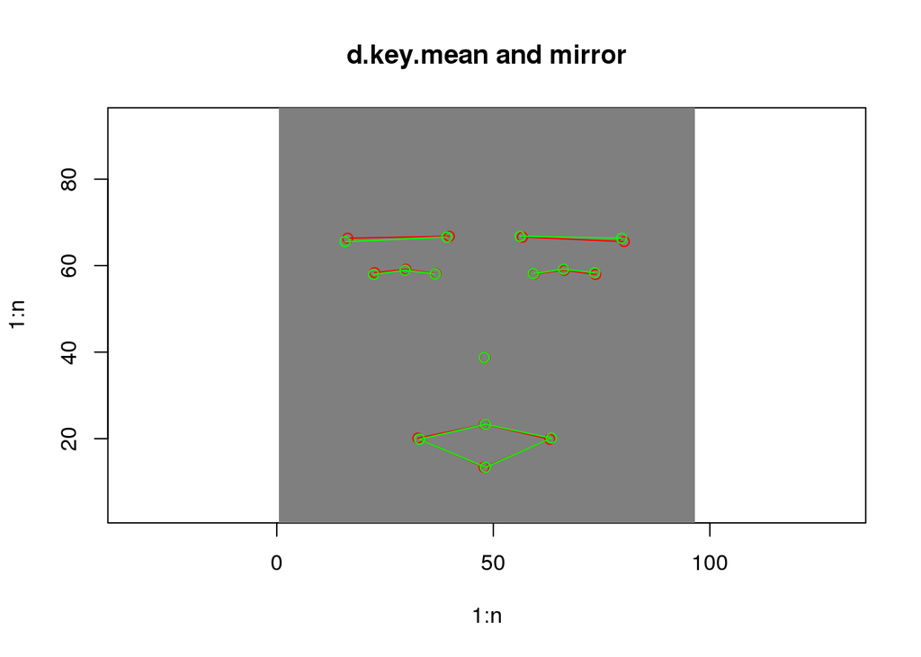

```r
m.plotImage()
m.plotKeypoints(d.key.mean, col="red")
m.plotKeypoints(m.mirrorKey(d.key.mean), col="green")
title(main="d.key.mean and mirror")
```

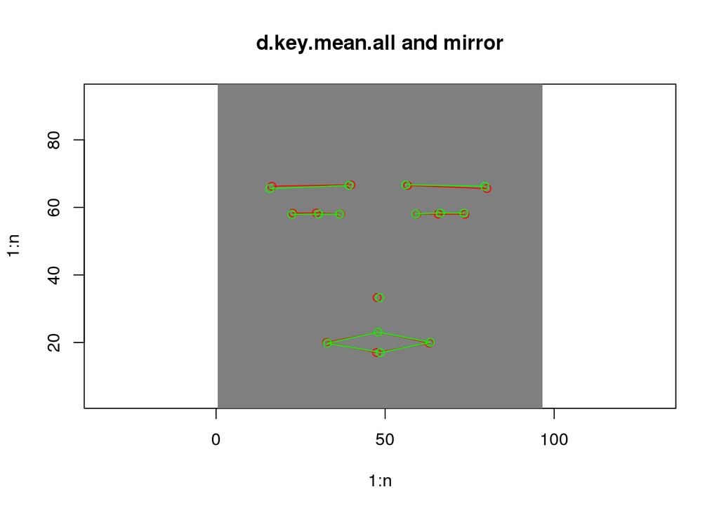

```r
m.plotImage()
m.plotKeypoints(d.key.mean.all, col="red")
m.plotKeypoints(m.mirrorKey(d.key.mean.all), col="green")
title(main="d.key.mean.all and mirror")
```

There does not seem to be any noticeable difference by symetry.

**We therefore decide to **adjust** both means for symetry**.

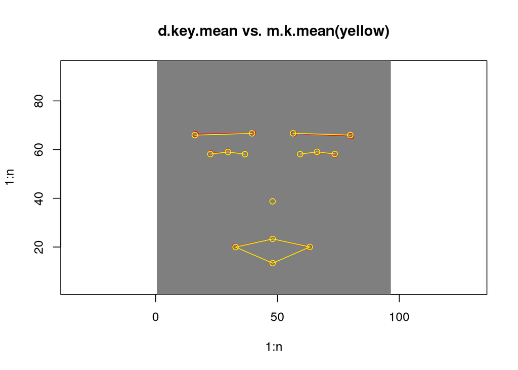

```r
m.key.mean <- (d.key.mean + m.mirrorKey(d.key.mean))/2
m.key.mean.all <- (d.key.mean.all + m.mirrorKey(d.key.mean.all))/2


m.plotImage()
m.plotKeypoints(d.key.mean, col="red")
m.plotKeypoints(m.key.mean, col="yellow")
title(main="d.key.mean vs. m.k.mean(yellow)")
```

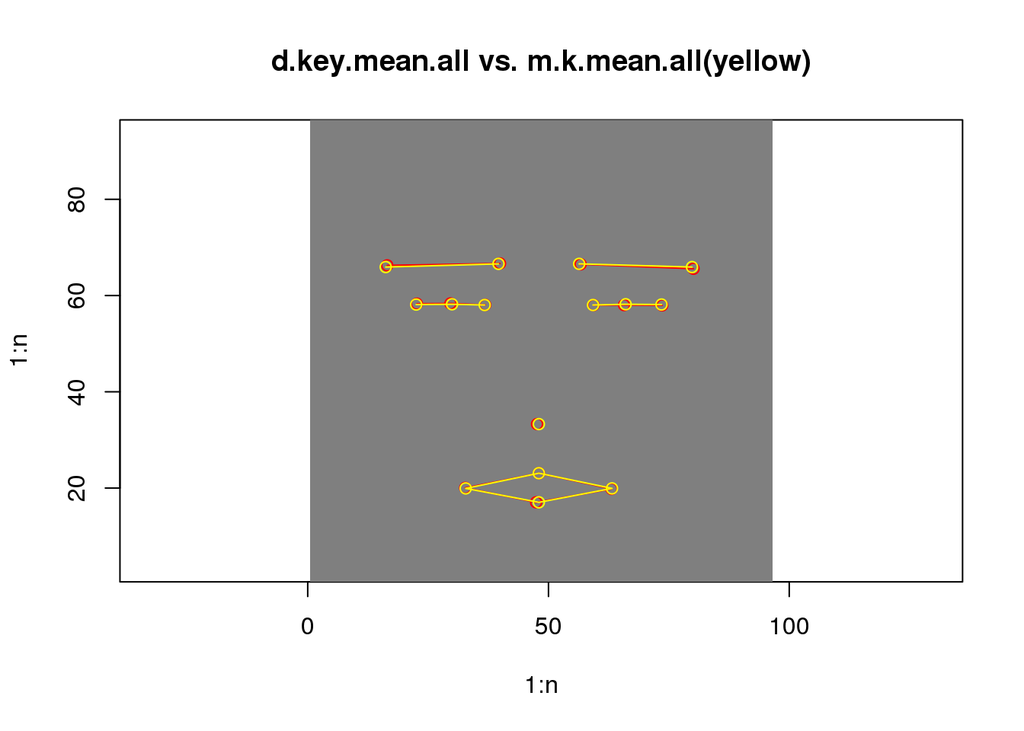

```r
m.plotImage()
m.plotKeypoints(d.key.mean.all, col="red")
m.plotKeypoints(m.key.mean.all, col="yellow")
title(main="d.key.mean.all vs. m.k.mean.all(yellow)")
```

## Considering adjusting missing elements ?

The massively missing elements, were we have only the nose, should probably not be adjusted. The rest is neglectable, and should probably be discarded.

For the time being, we would just focus on the complete examples :

```r
d.train.complete <- which(!is.na(rowSums(d.train)))
```

There are 2140 complete training records, out of the 7049 total training records.

## Cleaning and saving

We save selectively what we changed or created.

```r
save(d.train,d.key.mean,d.key.mean.all, m.key.mean,m.key.mean.all, d.train.complete,file="d.train.RData")
save(m.plotImage, m.plotKeypoints,m.mirrorKey,file="functions.viewing.RData")
```

*This file was compiled on Mon Jun 6 07:51:54 2016*